# Explore_bikeshare_data

### Explore Bike Share Data

For this project, your goal is to ask and answer three questions about the available bikeshare data from Washington, Chicago, and New York. This notebook can be submitted directly through the workspace when you are confident in your results.

You will be graded against the project [Rubric](https://review.udacity.com/#!/rubrics/2508/view) by a mentor after you have submitted. To get you started, you can use the template below, but feel free to be creative in your solutions!

```r
nyc = read.csv('new_york_city.csv')
wash = read.csv('washington.csv')
chic = read.csv('chicago.csv')
require(tidyverse)
```

```r
head(nyc)
```

| X | Start.Time | End.Time | Trip.Duration | Start.Station | End.Station | User.Type | Gender | Birth.Year |
| --- | --- | --- | --- | --- | --- | --- | --- | --- |
| 5688089 | 2017-06-11 14:55:05 | 2017-06-11 15:08:21 | 795 | Suffolk St & Stanton St | W Broadway & Spring St | Subscriber | Male | 1998 |
| 4096714 | 2017-05-11 15:30:11 | 2017-05-11 15:41:43 | 692 | Lexington Ave & E 63 St | 1 Ave & E 78 St | Subscriber | Male | 1981 |
| 2173887 | 2017-03-29 13:26:26 | 2017-03-29 13:48:31 | 1325 | 1 Pl & Clinton St | Henry St & Degraw St | Subscriber | Male | 1987 |
| 3945638 | 2017-05-08 19:47:18 | 2017-05-08 19:59:01 | 703 | Barrow St & Hudson St | W 20 St & 8 Ave | Subscriber | Female | 1986 |
| 6208972 | 2017-06-21 07:49:16 | 2017-06-21 07:54:46 | 329 | 1 Ave & E 44 St | E 53 St & 3 Ave | Subscriber | Male | 1992 |
| 1285652 | 2017-02-22 18:55:24 | 2017-02-22 19:12:03 | 998 | State St & Smith St | Bond St & Fulton St | Subscriber | Male | 1986 |

```r
head(wash)
```

| X | Start.Time | End.Time | Trip.Duration | Start.Station | End.Station | User.Type |
| --- | --- | --- | --- | --- | --- | --- |
| 1621326 | 2017-06-21 08:36:34 | 2017-06-21 08:44:43 | 489.066 | 14th & Belmont St NW | 15th & K St NW | Subscriber |
| 482740 | 2017-03-11 10:40:00 | 2017-03-11 10:46:00 | 402.549 | Yuma St & Tenley Circle NW | Connecticut Ave & Yuma St NW | Subscriber |
| 1330037 | 2017-05-30 01:02:59 | 2017-05-30 01:13:37 | 637.251 | 17th St & Massachusetts Ave NW | 5th & K St NW | Subscriber |
| 665458 | 2017-04-02 07:48:35 | 2017-04-02 08:19:03 | 1827.341 | Constitution Ave & 2nd St NW/DOL | M St & Pennsylvania Ave NW | Customer |
| 1481135 | 2017-06-10 08:36:28 | 2017-06-10 09:02:17 | 1549.427 | Henry Bacon Dr & Lincoln Memorial Circle NW | Maine Ave & 7th St SW | Subscriber |
| 1148202 | 2017-05-14 07:18:18 | 2017-05-14 07:24:56 | 398.000 | 1st & K St SE | Eastern Market Metro / Pennsylvania Ave & 7th St SE | Subscriber |

```r
head(chic)
```

| X | Start.Time | End.Time | Trip.Duration | Start.Station | End.Station | User.Type | Gender | Birth.Year |
| --- | --- | --- | --- | --- | --- | --- | --- | --- |
| 1423854 | 2017-06-23 15:09:32 | 2017-06-23 15:14:53 | 321 | Wood St & Hubbard St | Damen Ave & Chicago Ave | Subscriber | Male | 1992 |
| 955915 | 2017-05-25 18:19:03 | 2017-05-25 18:45:53 | 1610 | Theater on the Lake | Sheffield Ave & Waveland Ave | Subscriber | Female | 1992 |
| 9031 | 2017-01-04 08:27:49 | 2017-01-04 08:34:45 | 416 | May St & Taylor St | Wood St & Taylor St | Subscriber | Male | 1981 |
| 304487 | 2017-03-06 13:49:38 | 2017-03-06 13:55:28 | 350 | Christiana Ave & Lawrence Ave | St. Louis Ave & Balmoral Ave | Subscriber | Male | 1986 |
| 45207 | 2017-01-17 14:53:07 | 2017-01-17 15:02:01 | 534 | Clark St & Randolph St | Desplaines St & Jackson Blvd | Subscriber | Male | 1975 |
| 1473887 | 2017-06-26 09:01:20 | 2017-06-26 09:11:06 | 586 | Clinton St & Washington Blvd | Canal St & Taylor St | Subscriber | Male | 1990 |

### Question 1a

**What is the most common start station?**

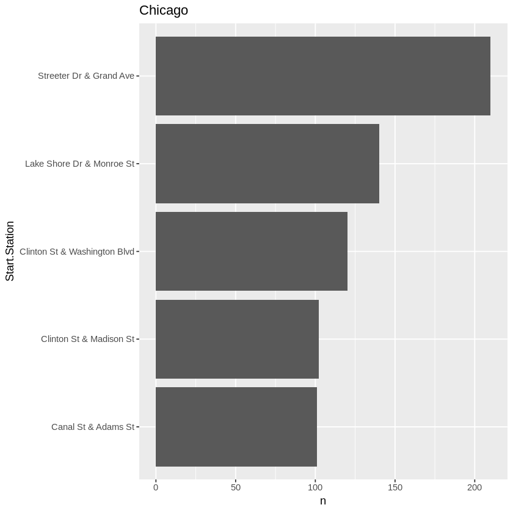

```r
start_stations <- chic %>%
  group_by(Start.Station) %>%
  summarise(n = n()) %>%
  arrange(desc(n)) %>%
  filter(n > 100) # graph had too much x variables wihout filter
ggplot(start_stations, aes(Start.Station, n))+
    geom_col()+
    labs(title = 'Chicago')+
    coord_flip()
```

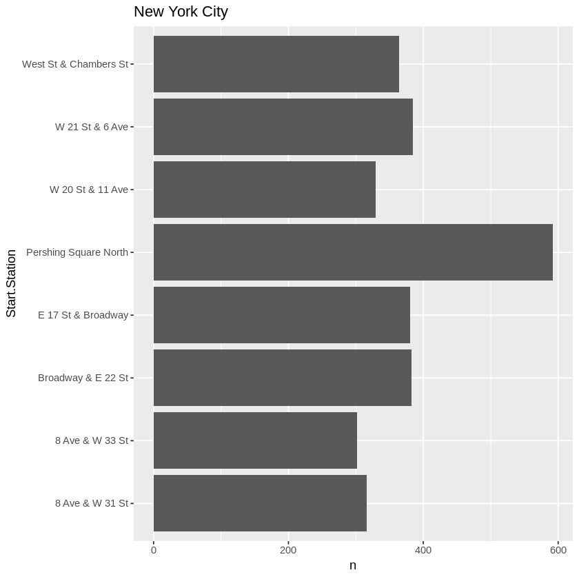

```r
start_stations <- nyc %>%
  group_by(Start.Station) %>%
  summarise(n = n()) %>%
  arrange(desc(n)) %>%
  filter(n > 300) # graph had too much x variables wihout filter

ggplot(start_stations, aes(Start.Station, n))+
  geom_col()+
  labs(title = 'New York City')+
    coord_flip()
```

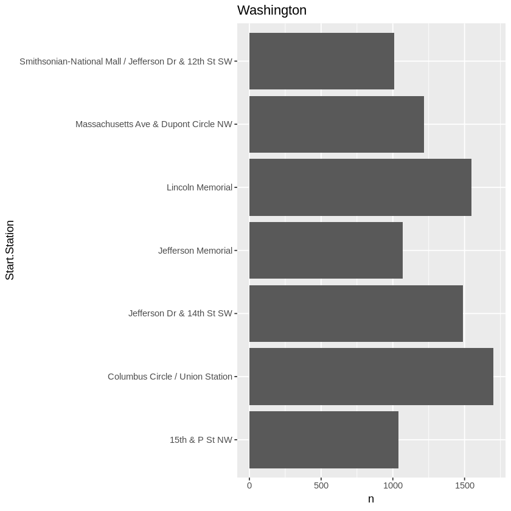

```r
start_stations <- wash %>%
  group_by(Start.Station) %>%
  summarise(n = n()) %>%
  arrange(desc(n)) %>%
  filter(n > 1000) # graph had too much x variables wihout filter

ggplot(start_stations, aes(Start.Station, n))+
  geom_col()+
  labs(title = 'Washington')+
  coord_flip()
```

The most common start station for Chicago is Streeter Dr & Grand Ave The most common start station for New York City is Pershing Square North The most common start station for Washington is Columbus Circle/ Union Station

The filter had to be used because the x variables were too many and unreadable. Coord_flip() was used to display the station names in their completeness

# Question 1b

**What is the most common end station?**

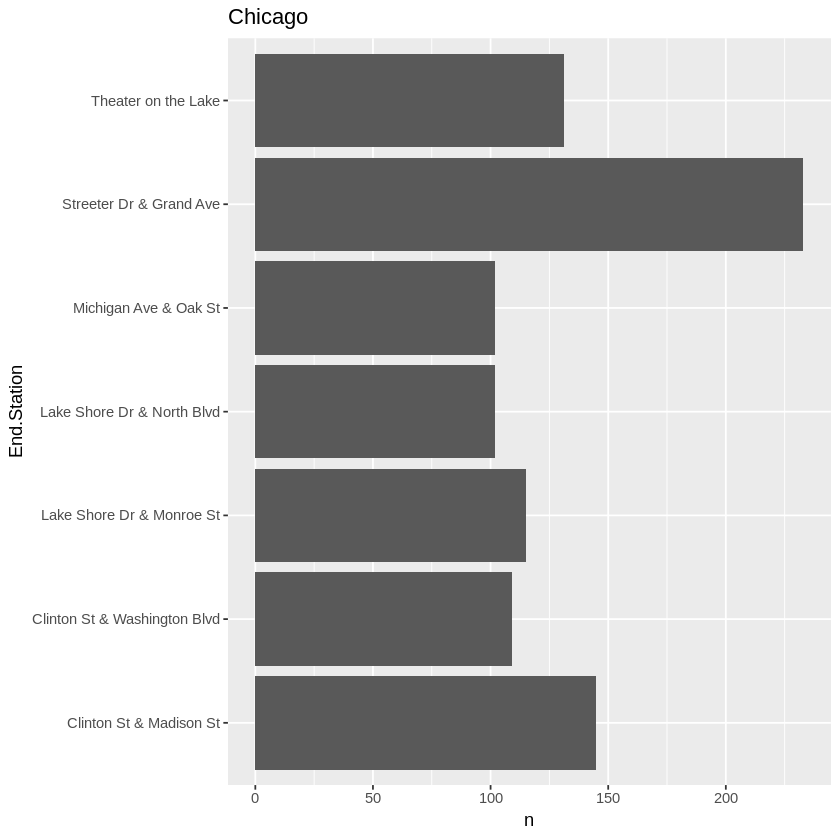

```r
end_stations <- chic %>%
  group_by(End.Station) %>%
  summarise(n = n()) %>%
  arrange(desc(n)) %>%
  filter(n > 100) # graph had too much x variables wihout filter


ggplot(end_stations, aes(End.Station, n))+
  geom_col()+
  coord_flip()+
  labs(title = 'Chicago')
```

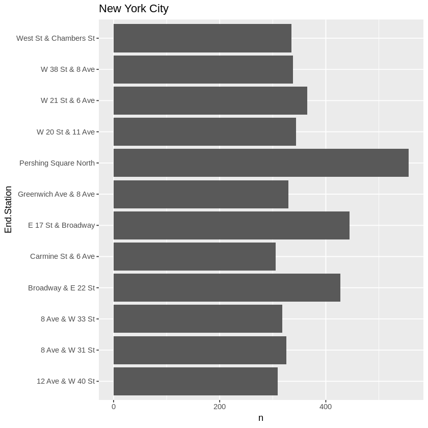

```r
end_stations <- nyc %>%
  group_by(End.Station) %>%
  summarise(n = n()) %>%
  arrange(desc(n)) %>%
  filter(n > 300) # graph had too much x variables wihout filter


ggplot(end_stations, aes(End.Station, n))+
  geom_col()+
  coord_flip()+
  labs(title = 'New York City')
```

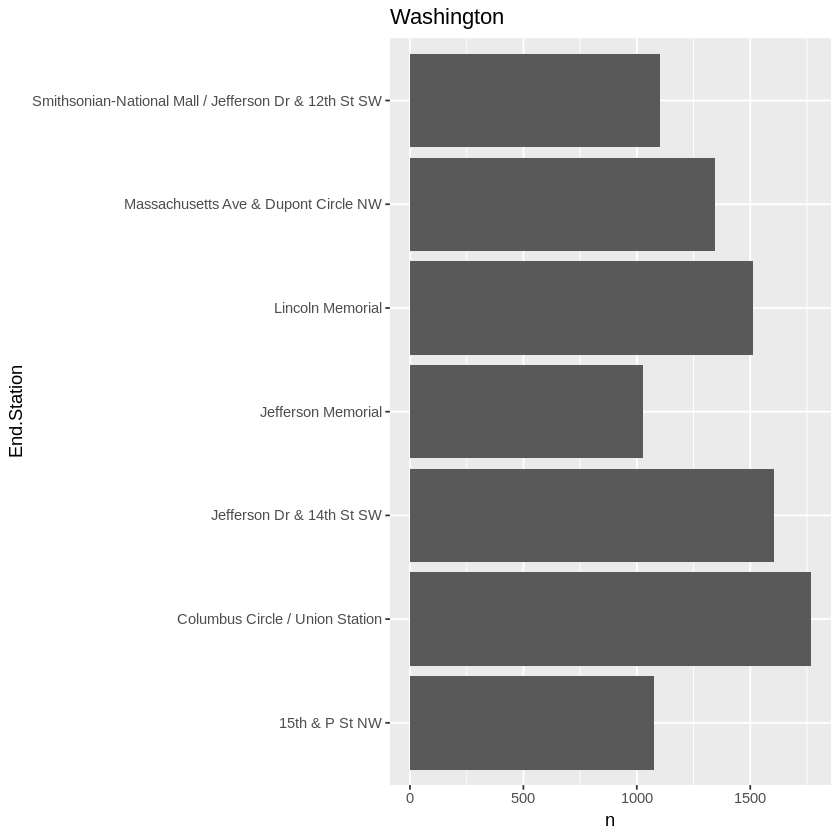

```r
end_stations <- wash %>%
  group_by(End.Station) %>%
  summarise(n = n()) %>%
  arrange(desc(n)) %>%
  filter(n > 1000) # graph had too much x variables wihout filter

ggplot(end_stations, aes(End.Station, n))+
  geom_col()+
  coord_flip()+
  labs(title = 'Washington')
```

**The most common end station for Chicago is Streeter Dr & Grand Ave The most common end station for New York City is Pershing Square North The most common end station for Washington is Columbus Circle/ Union Station

The filter had to be used because the x variables were too many and unreadable. Coord_flip() was used to display the station names in their completeness**

# Question 1c

**What is the most frequent combination of start and end stations?**

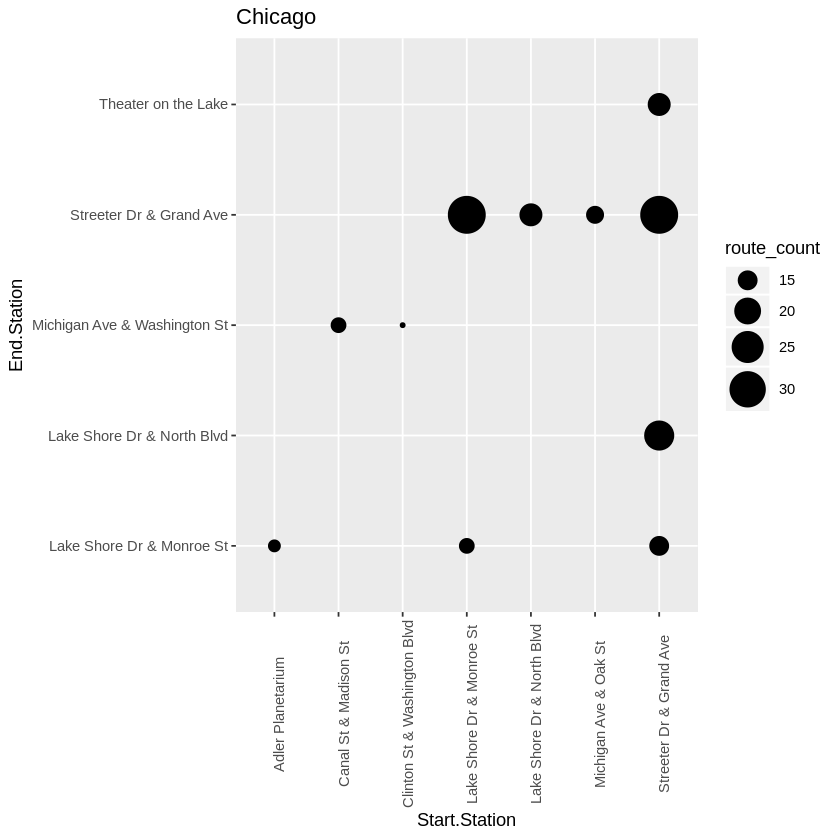

```r
routes <- chic %>%
  group_by(Start.Station,End.Station)%>%
  summarise(route_count = n()) %>%
  arrange(desc(route_count)) %>%
  filter(route_count>10)

ggplot(routes,aes(Start.Station, End.Station))+
  geom_point(aes(size = route_count))+
  scale_size(range = c(1,10))+
  labs(title = 'Chicago')+
  theme(axis.text.x = element_text(angle = 90))
```

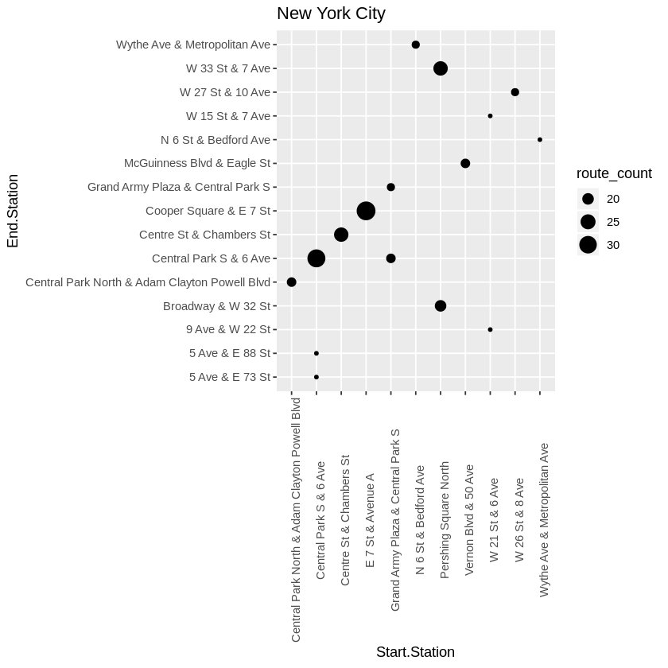

```r
routes <- nyc %>%
  group_by(Start.Station,End.Station)%>%
  summarise(route_count = n()) %>%
  arrange(desc(route_count)) %>%
  filter(route_count>15)

ggplot(routes,aes(Start.Station, End.Station))+
  geom_point(aes(size = route_count))+
  labs(title = 'New York City')+
  theme(axis.text.x = element_text(angle = 90))
```

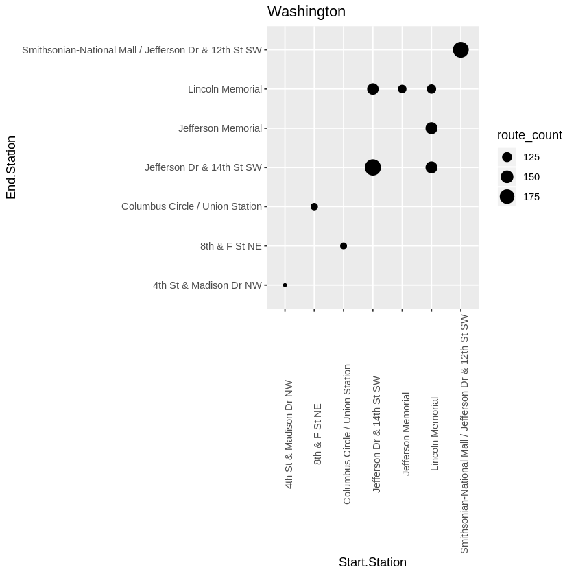

```r
routes <- wash %>%
  group_by(Start.Station,End.Station)%>%
  summarise(route_count = n()) %>%
  arrange(desc(route_count)) %>%
  filter(route_count>100)

ggplot(routes,aes(Start.Station, End.Station))+
  geom_point(aes(size = route_count))+
  labs(title = 'Washington')+
  theme(axis.text.x = element_text(angle = 90))
```

In Chicago, the most frequent route was from Streeter Dr/ Grand Ave and back to same location In New York City, the most frequent route was from E7 St & Avenue A to Cooper Square & E7 St. Notably is that closely following is round trip rides from Central Park/ 6TH Ave and back. In Washington, the most common route is the route from Jefferson Dr & 14th St SW and back. Closely following is another round trip from Smithsonian-National Mall / Jefferson Dr & 12th St SW and back